# Exploratory Data Analysis on Online Retail Data

**Overview:**  
In this notebook, I perform an exploratory data on the **online retail store** using R programming language. I leveraged third party library such as *dplyr, readr, stringr* etc. to help me perform the analysis easily and smoothly I also used the popular data visualization tool (ggplot2) to make all the visualizations and statistical plots.

**Data**  
The data contains transaction made within a period of 1 year of countries in Europe.

*Attributes:*  
**Invoice No.:** Unique Invoice Number of a customer  
**Stock Code :** Item code  
**Description:** Item description  
**Quantity:** Quantity of items purchased  
**Invoice Date:** Date of which the invoice was issued  
**Unit Price:** unit price an item  
**Customer ID:** unique id of a customer  
**Country:** country of a customer where the transaction was made

**--I focus my analysis on Germany only.**

**Analysis:**

- Sales by month
- Sales by day name
- Sales by day of the month
- Top frequent Items
- Top Items by Sales
- Sales by holiday (I merged the holiday data with the retail data) etc.

**Motive:**  
I did this project to showcase my skill in (exploratory data analysis) using R programming language.

```r
# loading the required libraries
options(warn=-1 )
library('dplyr')
library('magrittr')
library('ggplot2')
library('lubridate')
library('readxl')
library('readr')
#library('data.table')
library('rvest')
library('stringr')
library('scales')
#library('devtools')

theme_set(theme_light())
```

# Loading and Inspecting the Data

```r
# Loading and preparing the data.

ger_df = read_csv('data/germany.csv')
head(ger_df)

ger_df%>%
  rename('No.'= 'X1')%>%
  filter(`Quantity` >= 0)->ger_df
```

| X1 | Invoice No. | Stock Code | Description | Quantity | Invoice Date | Unit Price | Customer ID | Country |
| --- | --- | --- | --- | --- | --- | --- | --- | --- |
| 1 | 536527 | 22809 | SET OF 6 T-LIGHTS SANTA | 6 | 2010-12-01 13:04:00 | 2.95 | 12662 | Germany |
| 2 | 536527 | 84347 | ROTATING SILVER ANGELS T-LIGHT HLDR | 6 | 2010-12-01 13:04:00 | 2.55 | 12662 | Germany |
| 3 | 536527 | 84945 | MULTI COLOUR SILVER T-LIGHT HOLDER | 12 | 2010-12-01 13:04:00 | 0.85 | 12662 | Germany |
| 4 | 536527 | 22242 | 5 HOOK HANGER MAGIC TOADSTOOL | 12 | 2010-12-01 13:04:00 | 1.65 | 12662 | Germany |
| 5 | 536527 | 22244 | 3 HOOK HANGER MAGIC GARDEN | 12 | 2010-12-01 13:04:00 | 1.95 | 12662 | Germany |
| 6 | 536527 | 22243 | 5 HOOK HANGER RED MAGIC TOADSTOOL | 12 | 2010-12-01 13:04:00 | 1.65 | 12662 | Germany |

```r
glimpse(ger_df) # this code shows the datatype and some few observations of each columns of the data
```

```
Rows: 9,042
Columns: 9
$ No.            <dbl> 1, 2, 3, 4, 5, 6, 7, 8, 9, 10, 11, 12, 13, 14, 15, 31, ~
$ `Invoice No.`  <chr> "536527", "536527", "536527", "536527", "536527", "5365~
$ `Stock Code`   <chr> "22809", "84347", "84945", "22242", "22244", "22243", "~
$ Description    <chr> "SET OF 6 T-LIGHTS SANTA", "ROTATING SILVER ANGELS T-LI~
$ Quantity       <dbl> 6, 6, 12, 12, 12, 12, 24, 10, 10, 4, 12, 12, 12, 12, 1,~
$ `Invoice Date` <dttm> 2010-12-01 13:04:00, 2010-12-01 13:04:00, 2010-12-01 1~
$ `Unit Price`   <dbl> 2.95, 2.55, 0.85, 1.65, 1.95, 1.65, 0.42, 1.95, 1.95, 4~
$ `Customer ID`  <dbl> 12662, 12662, 12662, 12662, 12662, 12662, 12662, 12662,~
$ Country        <chr> "Germany", "Germany", "Germany", "Germany", "Germany", ~
```

```r
# getting the summary statistics of the data..
summary(ger_df)
```

```
      No.       Invoice No.         Stock Code        Description
 Min.   :   1   Length:9042        Length:9042        Length:9042
 1st Qu.:2450   Class :character   Class :character   Class :character
 Median :4794   Mode  :character   Mode  :character   Mode  :character
 Mean   :4783
 3rd Qu.:7131
 Max.   :9495
    Quantity       Invoice Date                   Unit Price
 Min.   :  1.00   Min.   :2010-12-01 13:04:00   Min.   :  0.000
 1st Qu.:  6.00   1st Qu.:2011-04-08 09:54:00   1st Qu.:  1.250
 Median : 10.00   Median :2011-07-20 14:38:00   Median :  1.950
 Mean   : 13.19   Mean   :2011-07-05 04:34:40   Mean   :  3.708
 3rd Qu.: 12.00   3rd Qu.:2011-10-11 12:38:00   3rd Qu.:  3.750
 Max.   :600.00   Max.   :2011-12-09 12:16:00   Max.   :599.500
  Customer ID      Country
 Min.   :12426   Length:9042
 1st Qu.:12481   Class :character
 Median :12600   Mode  :character
 Mean   :12649
 3rd Qu.:12662
 Max.   :14335
```

```r
# check for missing values
is.na(ger_df)%>%colSums()
```

**No.**

0

**Invoice No.**

0

**Stock Code**

0

**Description**

0

**Quantity**

0

**Invoice Date**

0

**Unit Price**

0

**Customer ID**

0

**Country**

0

```r
# We check our n's
ger_df%>%
  count(`Customer ID`)%>%
  summarise('Number of Unique Customers' = n())

ger_df%>%
summarise("Number of Observation" = n())
```

| Number of Unique Customers |
| --- |
| 94 |

| Number of Observation |
| --- |
| 9042 |

.

.

# Exploratory Data Analysis

```r
# top 3 and last 3 observation of the data
print('First 3 rows')
head(ger_df, 3)
print('Last 3 rows')
tail(ger_df,3)
```

```
[1] "First 3 rows"
```

| No. | Invoice No. | Stock Code | Description | Quantity | Invoice Date | Unit Price | Customer ID | Country |
| --- | --- | --- | --- | --- | --- | --- | --- | --- |
| 1 | 536527 | 22809 | SET OF 6 T-LIGHTS SANTA | 6 | 2010-12-01 13:04:00 | 2.95 | 12662 | Germany |
| 2 | 536527 | 84347 | ROTATING SILVER ANGELS T-LIGHT HLDR | 6 | 2010-12-01 13:04:00 | 2.55 | 12662 | Germany |
| 3 | 536527 | 84945 | MULTI COLOUR SILVER T-LIGHT HOLDER | 12 | 2010-12-01 13:04:00 | 0.85 | 12662 | Germany |

```
[1] "Last 3 rows"
```

| No. | Invoice No. | Stock Code | Description | Quantity | Invoice Date | Unit Price | Customer ID | Country |
| --- | --- | --- | --- | --- | --- | --- | --- | --- |
| 9493 | 581578 | 22908 | PACK OF 20 NAPKINS RED APPLES | 12 | 2011-12-09 12:16:00 | 0.85 | 12713 | Germany |
| 9494 | 581578 | 23215 | JINGLE BELL HEART ANTIQUE SILVER | 12 | 2011-12-09 12:16:00 | 2.08 | 12713 | Germany |
| 9495 | 581578 | 22736 | RIBBON REEL MAKING SNOWMEN | 10 | 2011-12-09 12:16:00 | 1.65 | 12713 | Germany |

.

.

## Checking for counts and distributions.

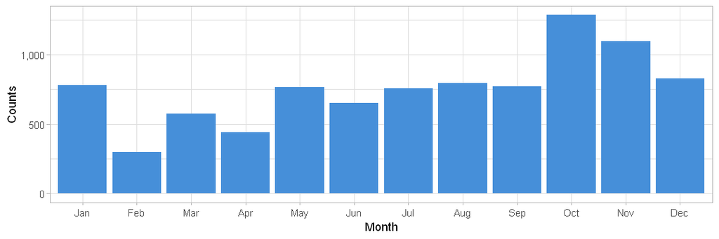

```r
# 1st we create a Month column of the data
ger_df%>%
  mutate('Month'= month((ger_df$`Invoice Date`)))->ger_df

# then we group by months and make a count of observation in each month
ger_df%>%
  group_by(`Month`)%>%
  count(`Month`)->month_count

# we create month name for the graph
month_name = c('Jan', 'Feb', 'Mar', 'Apr',
               'May', 'Jun', 'Jul', 'Aug', 'Sep',
               'Oct', 'Nov', 'Dec' )
month_count['month name'] = month_name

# then make plot of number of observation by each month
options(repr.plot.width =9, repr.plot.height = 3)
ggplot(data= month_count, mapping= aes(x = factor(`month name`, level= month_name) , y = `n`))+
  geom_bar(stat= 'identity', fill= '#468fd9')+
  scale_y_continuous(labels= comma, name= 'Counts')+scale_x_discrete(name= 'Month')
```

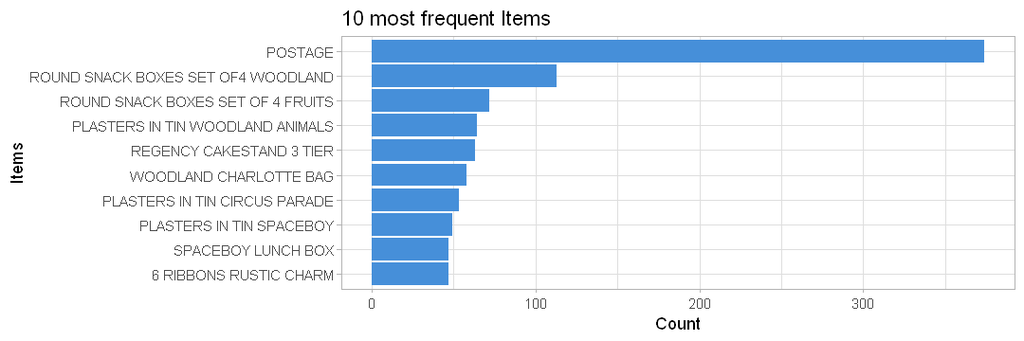

```r
# we group the data by the `Description` then make a count of observation in each `Description`
ger_df%>%
  group_by(`Description`)%>%
  count(`Description`)->descrp_count

# first and last 10 items..
descrp_count%>%
     arrange(desc(`n`))%>%head(10)->f_10

# plot of the first 10 counts in descending order
ggplot(data= f_10)+
  geom_bar(stat= 'identity', fill= '#468fd9', mapping= aes(x =reorder(`Description`, `n`)  , y =`n` ))+
coord_flip()+
scale_x_discrete(name= 'Items')+scale_y_continuous(name= 'Count')+
ggtitle('10 most frequent Items')
```

You notice that **POSTAGE** is the most frequent item in the data.

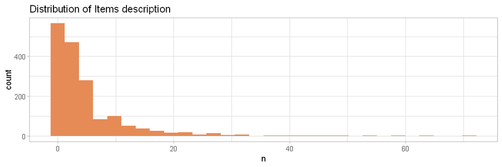

```r
# the code below makes a histogram of `Description` count.
ggplot(data= descrp_count%>%filter(`n` <= 100),  )+
geom_histogram(fill= '#e68b56', mapping = aes(x =`n`))+
ggtitle('Distribution of Items description')
```

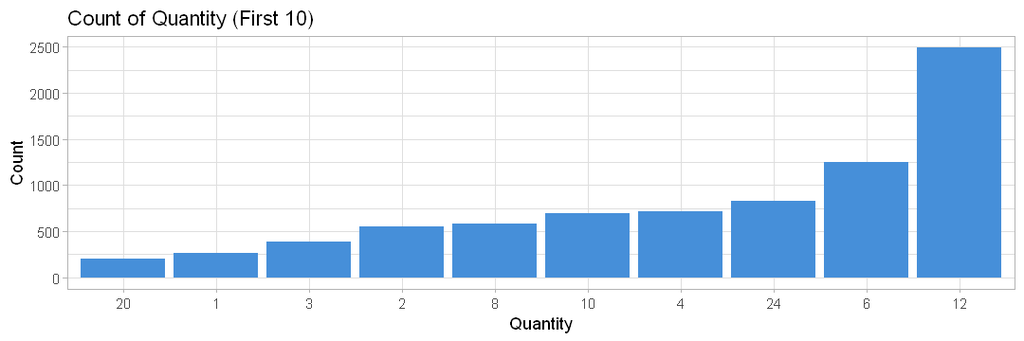

```r
# groups the data by `Quantity` and creates a count
ger_df%>%
  group_by(`Quantity`)%>%
  count(`Quantity`)%>%
     arrange(desc(`n`))%>%
   head(10)->f_10_qty

# plots the counts of `Quantity` in descending order.
ggplot(data= f_10_qty)+
  geom_bar(stat= 'identity', fill= '#468fd9', mapping= aes(x =reorder(`Quantity`, `n`)  , y =`n` ))+
scale_y_continuous(name= 'Count')+scale_x_discrete(name= 'Quantity')+
ggtitle('Count of Quantity (First 10)')
```

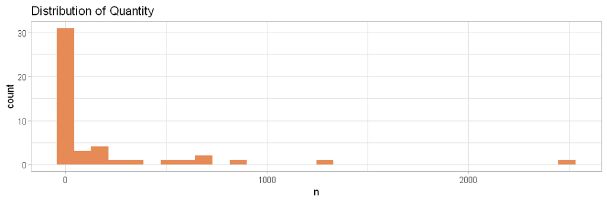

```r
# creates a histogram plot of `Quantity`
ggplot(data= ger_df%>%
            group_by(`Quantity`)%>%
             count(`Quantity`))+
geom_histogram(fill= '#e68b56', mapping = aes(x =`n`))+
ggtitle('Distribution of Quantity')
```

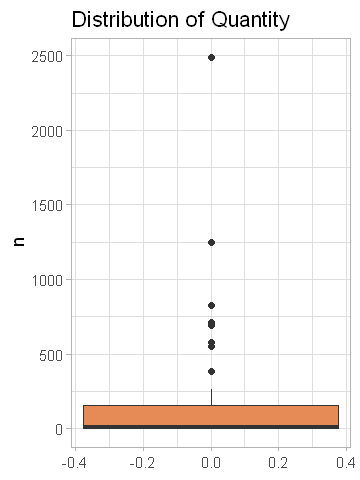

```r
# creates a Box-Whiskers plot of `Quantity`
options(repr.plot.width =3, repr.plot.height = 4)

ggplot(data= ger_df%>%
            group_by(`Quantity`)%>%
             count(`Quantity`))+
geom_boxplot(fill= '#e68b56', mapping = aes(y =`n`))+
ggtitle('Distribution of Quantity')
```

## 1. Sales by Customers.

```r
head(ger_df)
```

| No. | Invoice No. | Stock Code | Description | Quantity | Invoice Date | Unit Price | Customer ID | Country | Month |
| --- | --- | --- | --- | --- | --- | --- | --- | --- | --- |
| 1 | 536527 | 22809 | SET OF 6 T-LIGHTS SANTA | 6 | 2010-12-01 13:04:00 | 2.95 | 12662 | Germany | 12 |
| 2 | 536527 | 84347 | ROTATING SILVER ANGELS T-LIGHT HLDR | 6 | 2010-12-01 13:04:00 | 2.55 | 12662 | Germany | 12 |
| 3 | 536527 | 84945 | MULTI COLOUR SILVER T-LIGHT HOLDER | 12 | 2010-12-01 13:04:00 | 0.85 | 12662 | Germany | 12 |
| 4 | 536527 | 22242 | 5 HOOK HANGER MAGIC TOADSTOOL | 12 | 2010-12-01 13:04:00 | 1.65 | 12662 | Germany | 12 |
| 5 | 536527 | 22244 | 3 HOOK HANGER MAGIC GARDEN | 12 | 2010-12-01 13:04:00 | 1.95 | 12662 | Germany | 12 |
| 6 | 536527 | 22243 | 5 HOOK HANGER RED MAGIC TOADSTOOL | 12 | 2010-12-01 13:04:00 | 1.65 | 12662 | Germany | 12 |

```r
# creates a `Sales` column in the data.
ger_df%>%
  mutate('Sales' = `Quantity` * `Unit Price`)-> ger_df
```

```r
head(ger_df)
```

| No. | Invoice No. | Stock Code | Description | Quantity | Invoice Date | Unit Price | Customer ID | Country | Month | Sales |
| --- | --- | --- | --- | --- | --- | --- | --- | --- | --- | --- |
| 1 | 536527 | 22809 | SET OF 6 T-LIGHTS SANTA | 6 | 2010-12-01 13:04:00 | 2.95 | 12662 | Germany | 12 | 17.7 |
| 2 | 536527 | 84347 | ROTATING SILVER ANGELS T-LIGHT HLDR | 6 | 2010-12-01 13:04:00 | 2.55 | 12662 | Germany | 12 | 15.3 |
| 3 | 536527 | 84945 | MULTI COLOUR SILVER T-LIGHT HOLDER | 12 | 2010-12-01 13:04:00 | 0.85 | 12662 | Germany | 12 | 10.2 |
| 4 | 536527 | 22242 | 5 HOOK HANGER MAGIC TOADSTOOL | 12 | 2010-12-01 13:04:00 | 1.65 | 12662 | Germany | 12 | 19.8 |
| 5 | 536527 | 22244 | 3 HOOK HANGER MAGIC GARDEN | 12 | 2010-12-01 13:04:00 | 1.95 | 12662 | Germany | 12 | 23.4 |
| 6 | 536527 | 22243 | 5 HOOK HANGER RED MAGIC TOADSTOOL | 12 | 2010-12-01 13:04:00 | 1.65 | 12662 | Germany | 12 | 19.8 |

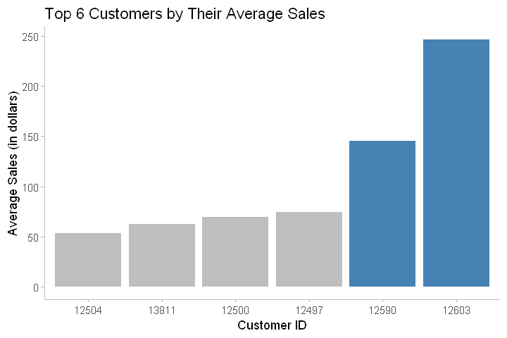

```r
# The code below creates `Sales per Customer` which is the average sales made by each customer and then
# Plots the Top 6 Sales by each customer.
ger_df%>%
    group_by(`Customer ID`)%>%
    summarise('Sales per Customer' = round(sum(Sales)/n(), 2))->sales_per_customer

options(repr.plot.width =6, repr.plot.height = 4)
ggplot(data= head(sales_per_customer%>%arrange(desc(`Sales per Customer`))))+
  geom_bar(stat= 'identity', fill= c(rep('grey', 4), rep('steelblue', 2)) ,
           mapping= aes(x =reorder(`Customer ID`, `Sales per Customer`)  , y =`Sales per Customer` ))+
scale_y_continuous(name= 'Average Sales (in dollars)')+scale_x_discrete(name= 'Customer ID')+
ggtitle('Top 6 Customers by Their Average Sales')+theme(panel.grid = element_blank(),
                                                  panel.border = element_blank(),
                                                   axis.line = element_line(colour= 'grey'))
```

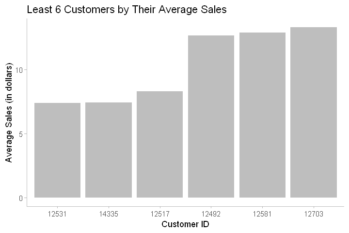

```r
ger_df%>%
    group_by(`Customer ID`)%>%
    summarise('Sales per Customer' = round(sum(Sales)/n(), 2))->sales_per_customer

options(repr.plot.width =6, repr.plot.height = 4)
ggplot(data= tail(sales_per_customer%>%arrange(desc(`Sales per Customer`))))+
  geom_bar(stat= 'identity', fill= 'grey' ,
           mapping= aes(x =reorder(`Customer ID`, `Sales per Customer`)  , y =`Sales per Customer` ))+
scale_y_continuous(name= 'Average Sales (in dollars)')+scale_x_discrete(name= 'Customer ID')+
ggtitle('Least 6 Customers by Their Average Sales')+theme(panel.grid = element_blank(),
                                                  panel.border = element_blank(),
                                                   axis.line = element_line(colour= 'grey'))
```

```r
sales_per_customer%>%arrange(sales_per_customer$`Sales per Customer`)%>%head()
```

[output not shown]

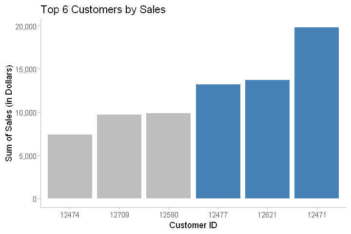

```r
# The code calculates the total sales made by each customer and then plot the top 6 customers per thier total sales.
ger_df%>%
 group_by(`Customer ID`)%>%
  summarise('Sum of Sales' = sum(Sales))%>%
  arrange(desc(`Sum of Sales`))->s

options(repr.plot.width =6, repr.plot.height = 4)
ggplot(data=head(s, 6))+
  geom_bar(stat= 'identity', fill= c(rep('grey', 3), rep('steelblue', 3)),
           mapping= aes(x =reorder(`Customer ID`, `Sum of Sales`)  , y =`Sum of Sales` ))+
scale_y_continuous(name= 'Sum of Sales (in Dollars)', label= comma)+scale_x_discrete(name= 'Customer ID')+
ggtitle('Top 6 Customers by Sales')+theme(panel.grid = element_blank(),
                                          panel.border = element_blank(),
                                         axis.line = element_line(colour= 'grey'))
```

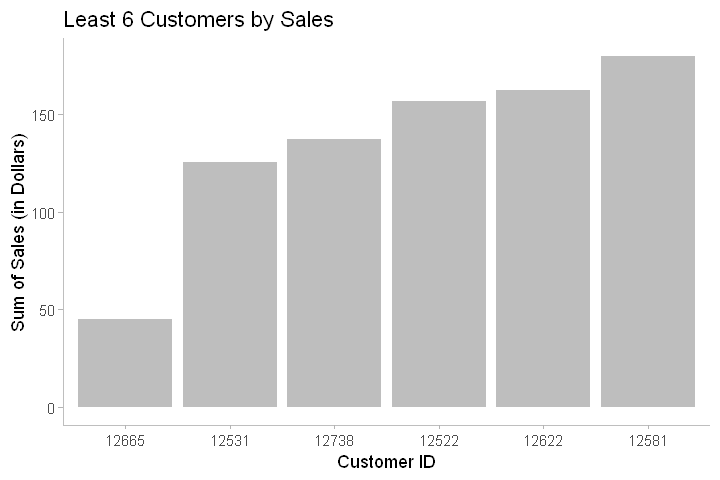

```r
ger_df%>%
 group_by(`Customer ID`)%>%
  summarise('Sum of Sales' = sum(Sales))%>%
  arrange(desc(`Sum of Sales`))->s

options(repr.plot.width =6, repr.plot.height = 4)
ggplot(data=tail(s, 6))+
  geom_bar(stat= 'identity', fill= 'grey',
           mapping= aes(x =reorder(`Customer ID`, `Sum of Sales`)  , y =`Sum of Sales` ))+
scale_y_continuous(name= 'Sum of Sales (in Dollars)', label= comma)+scale_x_discrete(name= 'Customer ID')+
ggtitle('Least 6 Customers by Sales')+theme(panel.grid = element_blank(),
                                          panel.border = element_blank(),
                                         axis.line = element_line(colour= 'grey'))
```

```r
# this code calculate the percentage of sales made by each customer.
s%>%mutate('% sales'= round(`Sum of Sales`/sum(`Sum of Sales`)*100, 2))%>%head(6)
```

| Customer ID | Sum of Sales | % sales |
| --- | --- | --- |
| 12471 | 19824.05 | 8.66 |
| 12621 | 13689.67 | 5.98 |
| 12477 | 13219.74 | 5.78 |
| 12590 | 9864.26 | 4.31 |
| 12709 | 9736.52 | 4.25 |
| 12474 | 7375.79 | 3.22 |

```r
# Alternative code for the one above...
xsum = sum(ger_df$Sales)
ger_df%>%
 group_by(`Customer ID`)%>%
  summarise('Sum of Sales' = sum(Sales))%>%
  arrange(desc(`Sum of Sales`))%>%
  mutate('Percentage' = round(`Sum of Sales`/xsum, 4))->x1
```

```r
x1%>%
arrange(x1$`Sum of Sales`)
```

[output not shown]

```r
# quantiles of sales -- customer level
print('Percentile distribution of sales (Customer Level).')
df = data.frame(quantile(s$`Sum of Sales`))
colnames(df) = 'Sales'
df
```

```
[1] "Percentile distribution of sales (Customer Level)."
```

[output not shown]

## 2. Sales by (Day of the Month)

```r
head(ger_df)
```

| No. | Invoice No. | Stock Code | Description | Quantity | Invoice Date | Unit Price | Customer ID | Country | Month | Sales |
| --- | --- | --- | --- | --- | --- | --- | --- | --- | --- | --- |
| 1 | 536527 | 22809 | SET OF 6 T-LIGHTS SANTA | 6 | 2010-12-01 13:04:00 | 2.95 | 12662 | Germany | 12 | 17.7 |
| 2 | 536527 | 84347 | ROTATING SILVER ANGELS T-LIGHT HLDR | 6 | 2010-12-01 13:04:00 | 2.55 | 12662 | Germany | 12 | 15.3 |
| 3 | 536527 | 84945 | MULTI COLOUR SILVER T-LIGHT HOLDER | 12 | 2010-12-01 13:04:00 | 0.85 | 12662 | Germany | 12 | 10.2 |
| 4 | 536527 | 22242 | 5 HOOK HANGER MAGIC TOADSTOOL | 12 | 2010-12-01 13:04:00 | 1.65 | 12662 | Germany | 12 | 19.8 |
| 5 | 536527 | 22244 | 3 HOOK HANGER MAGIC GARDEN | 12 | 2010-12-01 13:04:00 | 1.95 | 12662 | Germany | 12 | 23.4 |
| 6 | 536527 | 22243 | 5 HOOK HANGER RED MAGIC TOADSTOOL | 12 | 2010-12-01 13:04:00 | 1.65 | 12662 | Germany | 12 | 19.8 |

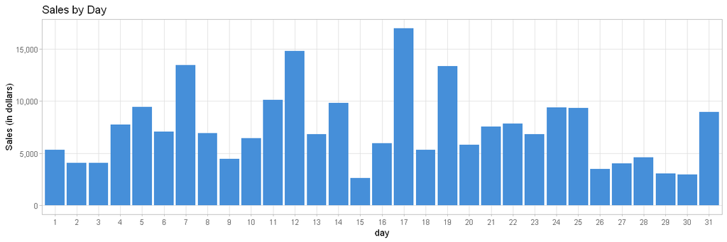

```r
# the code below creates the `day number` column
# and then calculates the sum of sales in each day
# and then plots the result.

ger_df%>%
  mutate('Day' = day(`Invoice Date`))->ger_df

ger_df%>%
 group_by(`Day`)%>%
  summarise('Sum of Sales' = sum(Sales))%>%
  arrange(`Day`)->d

options(repr.plot.width =12, repr.plot.height = 4)
days = seq(1:31)
#days = days[-c(9, 26)]

ggplot(data= d)+
  geom_bar(mapping=aes(x = factor(`Day`, level= days),
                       y= `Sum of Sales`), stat= 'identity', fill= '#468fd9')+
 scale_y_continuous(name= 'Sales (in dollars)', label= comma)+
 scale_x_discrete(labels= days, name= 'day')+
 ggtitle('Sales by Day')+theme(panel.grid.minor = element_blank())
```

# 3. Sales by Month

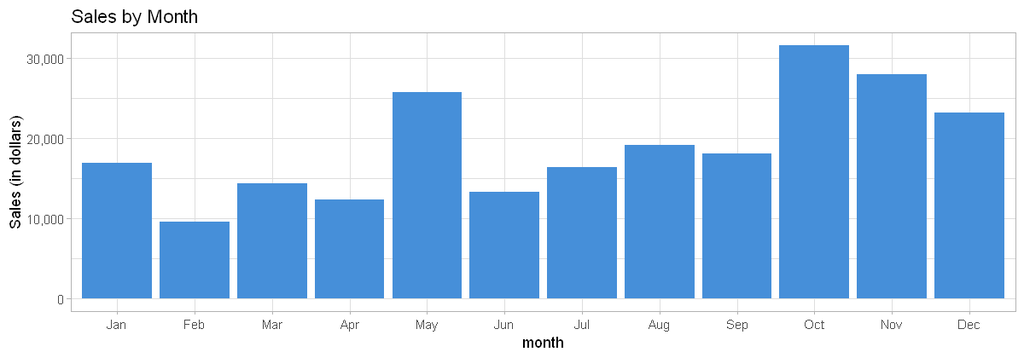

```r
# the code below creates the `month` column
# and then calculates the sum of sales in each month
# and then plots the result.

ger_df%>%
 group_by(`Month`)%>%
  summarise('Sum of Sales' = sum(Sales))%>%
  arrange(`Month`)->m
m['month name'] = month_name

options(repr.plot.width =10, repr.plot.height = 3.5)

ggplot(data= m)+
  geom_bar(mapping=aes(x = factor(`month name`, level= month_name),
                       y= `Sum of Sales`), stat= 'identity', fill= '#468fd9')+
 scale_y_continuous(name= 'Sales (in dollars)', label= comma)+
 scale_x_discrete(labels= month_name, name= 'month')+
 ggtitle('Sales by Month')
```

```r
# the code creates percentage of sales made in each month..
m%>%mutate('% of Sales'= round(`Sum of Sales`/sum(`Sum of Sales`)*100, 3))
```

| Month | Sum of Sales | month name | % of Sales |
| --- | --- | --- | --- |
| 1 | 16910.84 | Jan | 7.389 |
| 2 | 9581.05 | Feb | 4.186 |
| 3 | 14392.69 | Mar | 6.289 |
| 4 | 12315.54 | Apr | 5.381 |
| 5 | 25751.20 | May | 11.252 |
| 6 | 13274.10 | Jun | 5.800 |
| 7 | 16440.98 | Jul | 7.184 |
| 8 | 19220.77 | Aug | 8.398 |
| 9 | 18091.22 | Sep | 7.905 |
| 10 | 31638.42 | Oct | 13.824 |
| 11 | 28025.02 | Nov | 12.245 |
| 12 | 23225.31 | Dec | 10.148 |

## 4. Sales by Year

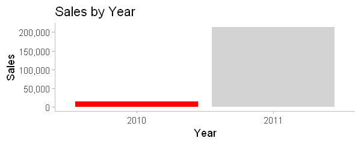

```r
# the code below creates the `year` column
# and then calculates the sum of sales in each year
# and then plots the result.

ger_df%>%
 mutate('Year' = year(`Invoice Date`))->ger_df

ger_df%>%
 group_by(`Year`)%>%
  summarise('Sum of Sales' = sum(Sales))%>%
  arrange(`Year`)->y

options(repr.plot.width =5, repr.plot.height = 2)
year_ = c('2010', '2011')
ggplot(data= y)+
          geom_bar(mapping=aes(x = factor(`Year`, year_),
                       y= `Sum of Sales`), stat= 'identity', fill= c(rep('red', 1), rep('lightgray', 1)) )+
 scale_y_continuous(name= 'Sales', label= comma)+
 scale_x_discrete(name= 'Year', labels= year_)+
 ggtitle('Sales by Year')+theme(panel.grid = element_blank(),
                                          panel.border = element_blank(),
                                         axis.line = element_line(colour= 'grey'))
```

```r
y
```

| Year | Sum of Sales |
| --- | --- |
| 2010 | 15241.14 |
| 2011 | 213626.00 |

```r
# Change in sales
diff(y$`Sum of Sales`)/sum(y$`Sum of Sales`)
```

0.866812334876907

```r
head(ger_df)
```

| No. | Invoice No. | Stock Code | Description | Quantity | Invoice Date | Unit Price | Customer ID | Country | Month | Sales | Day | Year |
| --- | --- | --- | --- | --- | --- | --- | --- | --- | --- | --- | --- | --- |
| 1 | 536527 | 22809 | SET OF 6 T-LIGHTS SANTA | 6 | 2010-12-01 13:04:00 | 2.95 | 12662 | Germany | 12 | 17.7 | 1 | 2010 |
| 2 | 536527 | 84347 | ROTATING SILVER ANGELS T-LIGHT HLDR | 6 | 2010-12-01 13:04:00 | 2.55 | 12662 | Germany | 12 | 15.3 | 1 | 2010 |
| 3 | 536527 | 84945 | MULTI COLOUR SILVER T-LIGHT HOLDER | 12 | 2010-12-01 13:04:00 | 0.85 | 12662 | Germany | 12 | 10.2 | 1 | 2010 |
| 4 | 536527 | 22242 | 5 HOOK HANGER MAGIC TOADSTOOL | 12 | 2010-12-01 13:04:00 | 1.65 | 12662 | Germany | 12 | 19.8 | 1 | 2010 |
| 5 | 536527 | 22244 | 3 HOOK HANGER MAGIC GARDEN | 12 | 2010-12-01 13:04:00 | 1.95 | 12662 | Germany | 12 | 23.4 | 1 | 2010 |
| 6 | 536527 | 22243 | 5 HOOK HANGER RED MAGIC TOADSTOOL | 12 | 2010-12-01 13:04:00 | 1.65 | 12662 | Germany | 12 | 19.8 | 1 | 2010 |

[figure not shown]

```r
# calculates sum of sales by eack week and then make plot of it.
ger_df%>%
 group_by('date'= floor_date(x = `Invoice Date`, unit= 'weekly'))%>%
 summarise('Sales'= sum(`Sales`))->wsales


ggplot(data= wsales)+
geom_area(mapping = aes(x = `Weekly`, y = `Sales`), color= 'steelblue',fill= '#468fd9', alpha =.43)+
ggtitle('sum of sales by made in each week')
```

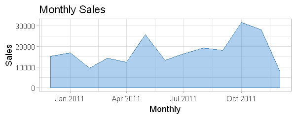

```r
# calculates sum of sales by eack month and then make plot of it.
ger_df%>%
 group_by('Monthly'= floor_date(x = `Invoice Date`, unit= 'monthly'))%>%
 summarise('Sales'= sum(`Sales`))->msales


ggplot(data= msales)+
geom_area(mapping = aes(x = `Monthly`, y = `Sales`), color= 'steelblue',fill= '#468fd9', alpha =.43)+
ggtitle('monthly sales')
```

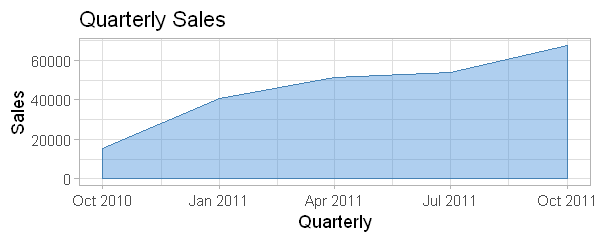

```r
# calculates sum of sales by eack quarter and then make plot of it.
ger_df%>%
 group_by('Quarterly'= floor_date(x = `Invoice Date`, unit= 'quarterly'))%>%
 summarise('Sales'= sum(`Sales`))->qsales


ggplot(data= qsales)+
geom_area(mapping = aes(x = `Quarterly`, y = `Sales`), color= 'steelblue',fill= '#468fd9', alpha =.43)+
ggtitle('Quarterly Sales')
```

## 5. Sales by Stocks

| Stock Code | Description | Total Sales | percentage |
| --- | --- | --- | --- |
| 22423 | REGENCY CAKESTAND 3 TIER | 9061.95 | 0.040 |
| 22326 | ROUND SNACK BOXES SET OF4 WOODLAND | 3598.95 | 0.016 |
| 22328 | ROUND SNACK BOXES SET OF 4 FRUITS | 1982.40 | 0.009 |
| 22629 | SPACEBOY LUNCH BOX | 1631.40 | 0.007 |
| 22554 | PLASTERS IN TIN WOODLAND ANIMALS | 1414.05 | 0.006 |
| 22625 | RED KITCHEN SCALES | 1339.60 | 0.006 |
| 22467 | GUMBALL COAT RACK | 1319.70 | 0.006 |
| 22077 | 6 RIBBONS RUSTIC CHARM | 1313.55 | 0.006 |
| 22556 | PLASTERS IN TIN CIRCUS PARADE | 1277.10 | 0.006 |
| 21731 | RED TOADSTOOL LED NIGHT LIGHT | 1201.20 | 0.005 |

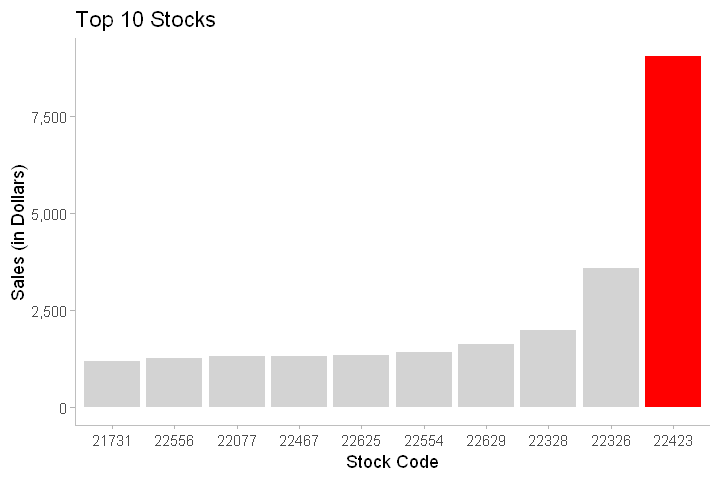

```r
# removes `POST` and `M` from `Stock Code` column
ger_df%>%filter(`Stock Code` != 'POST')%>%filter(`Stock Code` != 'M')->ger_df

# groups the data by `Stock Code` and `Description` then calculate the total sales for each Stock
# and fetch the first 10 in descending order and then plot of it.
ger_df%>%
  group_by(`Stock Code`, `Description`)%>%
  summarise('Total Sales' = sum(`Sales`))%>%
  arrange(desc(`Total Sales`))%>%head(10)->p

options(repr.plot.width =6, repr.plot.height = 4)
ggplot(data=p)+
  geom_bar(stat= 'identity', fill= c(rep('lightgray', 9), rep('red', 1)) ,
           mapping= aes(x =reorder(`Stock Code`, `Total Sales`)  , y =`Total Sales` ))+
scale_y_continuous(name= 'Sales (in Dollars)', label= comma)+scale_x_discrete(name= 'Stock Code')+
ggtitle('Top 10 Stocks')+theme(panel.grid = element_blank(),
                                          panel.border = element_blank(),
                                         axis.line = element_line(colour= 'grey'))

# creates the percentage of sales made by each stock
p%>%mutate('percentage'= round(`Total Sales`/xsum, 3))
```

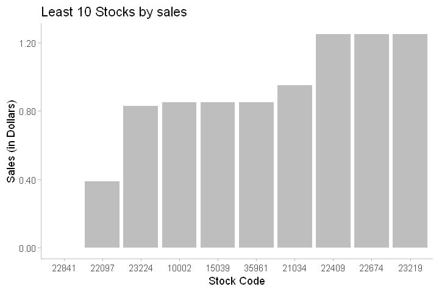

```r
ger_df%>%
  group_by(`Stock Code`, `Description`)%>%
  summarise('Total Sales' = sum(`Sales`))%>%
  arrange(desc(`Total Sales`))%>%tail(10)->p0

options(repr.plot.width =6, repr.plot.height = 4)
ggplot(data=p0)+
  geom_bar(stat= 'identity', fill= 'grey' ,
           mapping= aes(x =reorder(`Stock Code`, `Total Sales`)  , y =`Total Sales` ))+
scale_y_continuous(name= 'Sales (in Dollars)', label= comma)+scale_x_discrete(name= 'Stock Code')+
ggtitle('Least 10 Stocks by sales')+theme(panel.grid = element_blank(),
                                          panel.border = element_blank(),
                                         axis.line = element_line(colour= 'grey'))
```

## 6. Quantity by Stock

| Stock Code | Description | Total Quantity | percentage |
| --- | --- | --- | --- |
| 22326 | ROUND SNACK BOXES SET OF4 WOODLAND | 1233 | 0.010 |
| 15036 | ASSORTED COLOURS SILK FAN | 1164 | 0.010 |
| 20719 | WOODLAND CHARLOTTE BAG | 1020 | 0.009 |
| 21212 | PACK OF 72 RETROSPOT CAKE CASES | 1002 | 0.008 |
| 22585 | PACK OF 6 BIRDY GIFT TAGS | 936 | 0.008 |
| 22629 | SPACEBOY LUNCH BOX | 876 | 0.007 |
| 22554 | PLASTERS IN TIN WOODLAND ANIMALS | 857 | 0.007 |
| 22961 | JAM MAKING SET PRINTED | 816 | 0.007 |
| 22423 | REGENCY CAKESTAND 3 TIER | 809 | 0.007 |
| 16045 | POPART WOODEN PENCILS ASST | 800 | 0.007 |

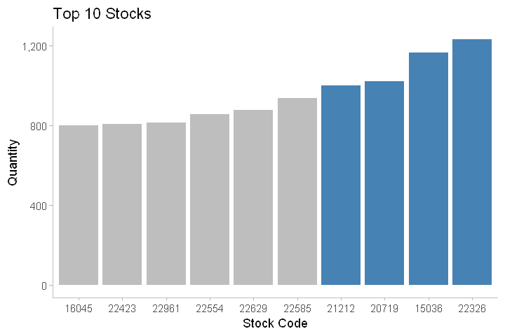

```r
# groups the data by `Stock Code` and `Description` then calculate the total quantity sold for each Stock
# and fetch the first 10 in descending order and then plot of it.
ger_df%>%
  group_by(`Stock Code`, `Description`)%>%
  summarise('Total Quantity' = sum(`Quantity`))%>%
  arrange(desc(`Total Quantity`))%>%head(10)->q

options(repr.plot.width =6, repr.plot.height = 4)
ggplot(data=q)+
  geom_bar(stat= 'identity', fill= c(rep('grey', 6), rep('steelblue', 4)),
           mapping= aes(x =reorder(`Stock Code`, `Total Quantity`)  , y =`Total Quantity` ))+
scale_y_continuous(name= 'Quantity', label= comma)+scale_x_discrete(name= 'Stock Code')+
ggtitle('Top 10 Stocks')+theme(panel.grid = element_blank(),
                                          panel.border = element_blank(),
                                         axis.line = element_line(colour= 'grey'))

# creates the percentage of quantity sold by each stock
qsum = sum(ger_df$Quantity)
q%>%mutate('percentage'= round(`Total Quantity`/qsum, 3))
```

## 7. Do holidays affect Sales or Demand ?

```r
# this external data source contains the holidays in Germany and its date.
hol= read_excel(path = 'data/holidays.xlsx')
```

```r
head(hol)
```

| day | month | year | holiday |
| --- | --- | --- | --- |
| 1 | May | 2010 | Labour Day |
| 3 | Oct | 2010 | German Unity Day |
| 31 | Oct | 2010 | Reformation Day |
| 1 | Nov | 2010 | All Saints Day |
| 25 | Dec | 2010 | Christmas Day |
| 26 | Dec | 2010 | St. Stephen's Day |

```r
colnames(ger_df)
```

1. 'No.'

2. 'Invoice No.'

3. 'Stock Code'

4. 'Description'

5. 'Quantity'

6. 'Invoice Date'

7. 'Unit Price'

8. 'Customer ID'

9. 'Country'

10. 'Month'

11. 'Sales'

12. 'Day'

13. 'Year'

```r
# fetch the month and month name from
# the month_count data created in In[8] and then merge the mth_df to the original data
# and then assign it to a variable p1
mth_df= month_count%>%
         select(`Month`,`month name`)
ger_df%>%
  merge(mth_df, by= 'Month')->p1

# we then create an innerjoin of day and month column of the p1 data and the holiday data
# and assign it to ger_df2
p1%>%
inner_join(hol, by=c('Day'= 'day', 'month name'= 'month'))->ger_df2
```

```r
head(ger_df2)
```

| Month | No. | Invoice No. | Stock Code | Description | Quantity | Invoice Date | Unit Price | Customer ID | Country | Sales | Day | Year | month name | year | holiday |
| --- | --- | --- | --- | --- | --- | --- | --- | --- | --- | --- | --- | --- | --- | --- | --- |
| 2 | 1589 | 543833 | 21621 | VINTAGE UNION JACK BUNTING | 2 | 2011-02-14 10:24:00 | 8.50 | 12476 | Germany | 17.0 | 14 | 2011 | Feb | 2010 | Valentine's Day |
| 2 | 1589 | 543833 | 21621 | VINTAGE UNION JACK BUNTING | 2 | 2011-02-14 10:24:00 | 8.50 | 12476 | Germany | 17.0 | 14 | 2011 | Feb | 2011 | Valentine's Day |
| 2 | 1590 | 543833 | 22722 | SET OF 6 SPICE TINS PANTRY DESIGN | 4 | 2011-02-14 10:24:00 | 3.95 | 12476 | Germany | 15.8 | 14 | 2011 | Feb | 2010 | Valentine's Day |
| 2 | 1590 | 543833 | 22722 | SET OF 6 SPICE TINS PANTRY DESIGN | 4 | 2011-02-14 10:24:00 | 3.95 | 12476 | Germany | 15.8 | 14 | 2011 | Feb | 2011 | Valentine's Day |
| 2 | 1588 | 543833 | 22957 | SET 3 PAPER VINTAGE CHICK PAPER EGG | 6 | 2011-02-14 10:24:00 | 2.95 | 12476 | Germany | 17.7 | 14 | 2011 | Feb | 2010 | Valentine's Day |
| 2 | 1588 | 543833 | 22957 | SET 3 PAPER VINTAGE CHICK PAPER EGG | 6 | 2011-02-14 10:24:00 | 2.95 | 12476 | Germany | 17.7 | 14 | 2011 | Feb | 2011 | Valentine's Day |

## 8. Sales by Holiday

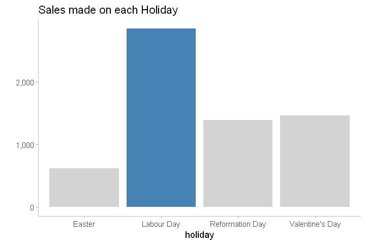

```r
# the code groups the data by holiday and then calculates the total sales made in each holiday period
# we then assign the resulting data to a variable h.
# and then make a plot of total sales by holiday...
ger_df2%>%
  group_by(`holiday`)%>%
  summarise('Total Sales'= sum(`Sales`))->h


ggplot(data= h)+
geom_bar(mapping= aes(y= `Total Sales`, x = `holiday`), stat = 'identity',
         fill= c(rep('lightgray', 1), rep('steelblue', 1), rep('lightgray', 2)) )+
scale_y_continuous(name='', labels= comma)+theme(panel.grid = element_blank(),
                                          panel.border = element_blank(),
                                         axis.line = element_line(colour= 'grey'))+
ggtitle('Sales made on each Holiday')
```

```r
h%>%mutate('%perc'= h$`Total Sales`/sum(h$`Total Sales`)) # create a percentage sales made in each month column...
```

| holiday | Total Sales | %perc |
| --- | --- | --- |
| Easter | 620.29 | 0.09809562 |
| Labour Day | 2850.99 | 0.45086916 |
| Reformation Day | 1391.06 | 0.21998887 |
| Valentine's Day | 1460.98 | 0.23104635 |

```r
# calculates the sum of sales and group them by holiday and description
# and then assign it to the gifts_data variable..
ger_df2%>%
group_by(`holiday`, `Description`)%>%
summarise('Sales' = sum(Sales))-> gifts_data
```

## 9. Sales by Day Name

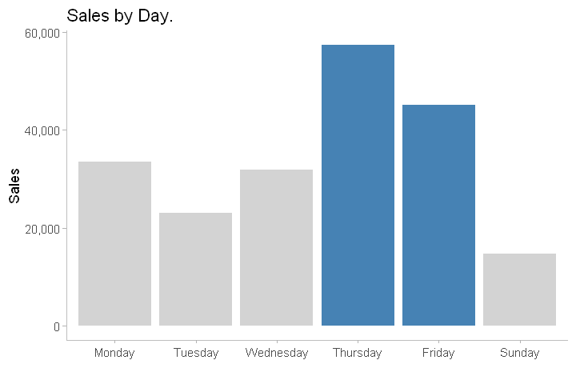

```r
# creates the weekday variable to the data
# then calculate the sum of sales made in each week day
# we then make a plot of it..
ger_df%>%mutate('week day'= weekdays(`Invoice Date`))->ger_df
ger_df%>%
group_by(`week day`)%>%
summarise('sales'= sum(`Sales`))->d2

dayname = c('Monday', 'Tuesday','Wednesday', 'Thursday', 'Friday', 'Sunday' )

options(repr.plot.width =6, repr.plot.height = 4)
chrome = c(rep('lightgray', 3), rep('steelblue', 2), 'lightgray')
ggplot(data= d2)+
geom_bar(stat='identity', aes(x= factor(`week day`, level= dayname), y = `sales`), fill= chrome)+
scale_y_continuous(labels= comma, name= 'Sales')+scale_x_discrete(name= '')+
ggtitle('Sales by Day.')+theme(panel.grid = element_blank(),
                                          panel.border = element_blank(),
                                         axis.line = element_line(colour= 'grey'))
```

```r
# creates % sales made in each weekday...
d2%>%mutate('% sales'= round(`sales`/sum(d2$sales)*100, 2))
```

| week day | sales | % sales |
| --- | --- | --- |
| Friday | 45035.98 | 21.91 |
| Monday | 33520.99 | 16.31 |
| Sunday | 14754.52 | 7.18 |
| Thursday | 57378.04 | 27.91 |
| Tuesday | 22981.97 | 11.18 |
| Wednesday | 31898.39 | 15.52 |

```r
# the code below saves the sum of sales made in each holiday
gifts_data%>%
filter(`holiday` == 'Easter')%>%write.csv('output/easter-day.csv')

gifts_data%>%
filter(`holiday` == 'Labour Day')%>%write.csv('output/labour-day.csv')

gifts_data%>%
filter(`holiday` == 'Reformation Day')%>%write.csv('output/reformation-day.csv')

gifts_data%>%
filter(`holiday` == "Valentine's Day")%>%write.csv('output/val-day.csv')
```

## 10. Concluding Question

1. Why was 2010 sales incredibly low as compared to 2011 sales.?
2. Does holidays really affect sales?
3. Do I really have enough data to answer the previous questions?